# Report on study `Test_2022` from

## Numerical traits

### branch_mass_fraction

We aligned the contributed variable called `branch mass fraction` in the data you supplied with the trait `branch_mass_fraction` in the AusTraits database, with value_types `mean`.

The original variable was supplied with units `mg/mg`; these were converted to our standard `mg/mg`.

The data has the following properties:

- **standardised name**: branch_mass_fraction
- **standardised description**: A plant dry mass trait [TO:0000352] which is the ratio [PATO:0001470] of side branch [PO:0025073] dry [PATO:0001824] mass [PATO:0000125] to whole plant [PO:0000003] dry mass.;The ratio of side branch dry mass to whole plant dry mass. That is, the proportion of total plant biomass that is comprised of all branches off the main shoot axis.
- **label**: Side branch dry mass to whole plant dry mass ratio
- **units**: mg/mg
- **records**: 45 in this study (of 45 in AusTraits)
- **allowable range**: 0 - 1 mg/mg
- **observed range in this study**: 0 - 0.71 mg/mg

Data for this trait in this study were collected using the following methods:

- **value_type**: mean
- **replicates**: 3
- **methods**: Branch mass fraction was calculated as the mass side branches/total mass, on a carbon dry mass basis. The zero values are correct - these are plants with no branches.

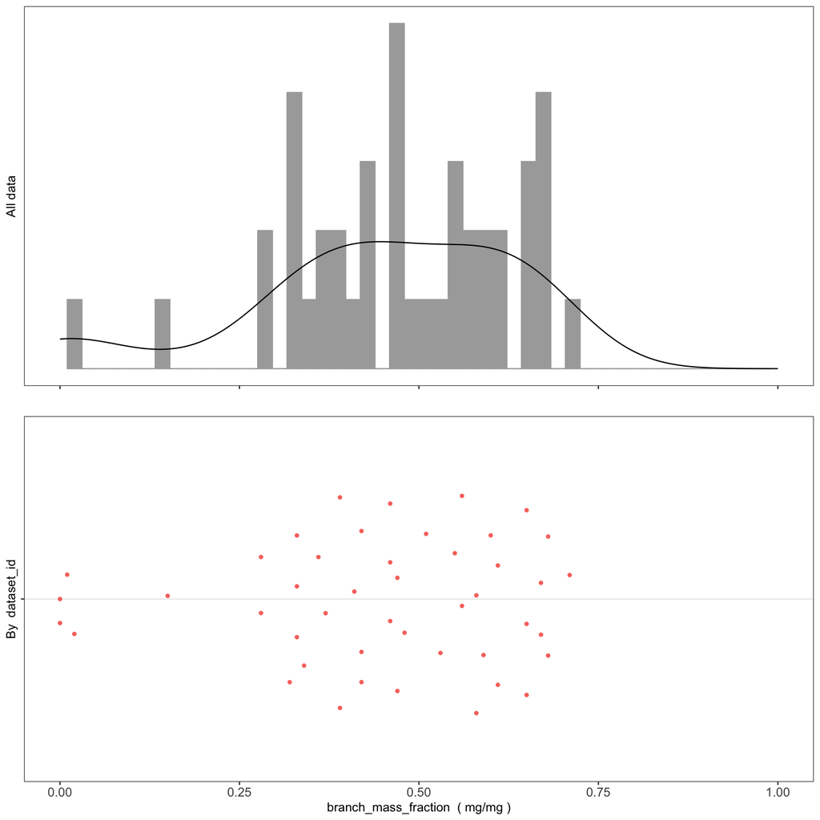

OUTLIERS: 3 of points in your dataset lie in either the bottom or top 2.5 percent of data

**Question:** (section `traits`) Do the data for the trait `branch_mass_fraction` appear correct?

### huber_value

We aligned the contributed variable called `LASA10, LASA250, LASA50, LASA1000` in the data you supplied with the trait `huber_value` in the AusTraits database, with value_types `mean, mean, mean, mean`.

The original variable was supplied with units `mm2{leaf}/mm2{sapwood}`; these were converted to our standard `mm2{sapwood}/mm2{leaf}`.

The data has the following properties:

- **standardised name**: huber_value
- **standardised description**: A stem morphology trait [TO:0000361] which is the ratio [PATO:0001470] of sapwood [PO:0004513] area [PATO:0001323] to the total distal [PATO:0001234] leaf [PO:0025034] area.;For a single branch, the ratio of sapwood cross-sectional area at the base of the branch to the branch’s total leaf area.
- **label**: Huber value
- **units**: mm2{sapwood}/mm2{leaf}
- **records**: 152 in this study (of 152 in AusTraits)
- **allowable range**: 1e-06 - 0.2 mm2{sapwood}/mm2{leaf}
- **observed range in this study**: 8.12743823146944e-05 - 0.000718907260963336 mm2{sapwood}/mm2{leaf}

Data for this trait in this study were collected using the following methods:

- **value_type**: mean, mean, mean, mean
- **replicates**: 3, 3, 3, 3
- **methods**: Leaf area was determined for a shoot whose sapwood had a cross sectional area of 10 mm2. In detail from Wright_2006, which used this data, No single best point exists to compare traits such as LM/ SM, LA/SM and LA/SA when considering a set of species that varies widely in canopy architecture and typical maximum height (here, approximately 20 cm to 85 m). We have used several approaches (Table 1). In one study, we made measurements on the terminal twigs of each species, i.e. on a relatively standard developmental unit (Westoby and Wright 2003). For species at Ash, GLP, Myall and TRF, traits were measured at each of several different distances back down the stem from the branch tip (Falster and Westoby 2005a, 2005b and unpublished, Pickup et al. 2005). At GHP, RHM and RHW, traits were measured at a standard sapwood cross-sectional area (10 mm2; Pickup et al. 2005). For the present re-analysis, we took the raw data from the previous studies and, for every species possible, calculated patterns of leaf and stem deployment at two standard points: at 250 mm distance from the branch tip (Ash, GLP, Myall and TRF) and at 10 mm2 stem (Ash, Myall, TRF) or sapwood (GHP, GLP, RHM, RHW) crosssectional area (250 mm or 10 mm2 formulation denoted as subscript in trait abbreviations). This was done as follows. For each individual plant, total leaf and stem dry mass at 250 mm distance was estimated by straightline interpolation from values measured at the nearest sampling points on either side of this distance. As the dry mass data tended to display non-linear (power) relationships with distance from the branch tip, the interpolated values were calculated from log10-log10- transformed data, then back-transformed to the original scale. The same approach was used for interpolating data to the standard stem (or sapwood) cross-sectional area. For individuals where measurements had not been made on either side of the desired point but the nearest measurement had been made within 25 mm of 250 mm or 1 mm2 of 10 mm2 cross-section (i.e. within 10% of the desired point), we extrapolated (rather than interpolated) the measured data to the standard point. This allowed us to include a number of individuals and species for which interpolation was not possible. Still, several large-leaved, large-stemmed species from the TRF site could not be included in the 10-mm2 crosssection dataset. No unusual tendencies in analyses, including the extrapolated data, were seen in comparison to analyses including interpolated data only (details not shown). To illustrate how species’ morphology varied at the two standard sampling points, species-mean stem cross-sectional area varied between 1.2 and 258 mm2 at 250 mm distance from the branch tip, while the distance from the branch tip at which stem cross-sectional area reached 10 mm2 varied from 64 to 995 mm.

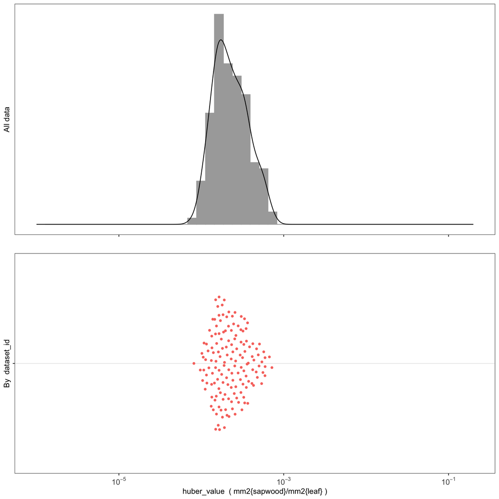

OUTLIERS: 7 of points in your dataset lie in either the bottom or top 2.5 percent of data

**Question:** (section `traits`) Do the data for the trait `huber_value` appear correct?

### leaf_N_per_dry_mass

We aligned the contributed variable called `Leaf nitrogen (mg mg-1)` in the data you supplied with the trait `leaf_N_per_dry_mass` in the AusTraits database, with value_types `mean`.

The original variable was supplied with units `mg/mg`; these were converted to our standard `mg/g`.

The data has the following properties:

- **standardised name**: leaf_N_per_dry_mass
- **standardised description**: The ratio [PATO:0001470] of the mass [PATO:0000125] of nitrogen [CHEBI:25555] in a leaf [PO:0025034] to leaf dry mass [TO:0001014].
- **label**: Leaf nitrogen (N) content per unit leaf dry mass
- **units**: mg/g
- **records**: 45 in this study (of 45 in AusTraits)
- **allowable range**: 0.5 - 100 mg/g
- **observed range in this study**: 9.6 - 35.2 mg/g

Data for this trait in this study were collected using the following methods:

- **value_type**: mean
- **replicates**: 3
- **methods**: Leaves from all individuals per species were pooled and finely ground for nitrogen analysis. Total nitrogen concentration (%) was measured using complete combustion gas chromatography by Waite Analytical Services, Adelaide. The first five fully expanded leaves at the tip of each individual were used for the analysis.

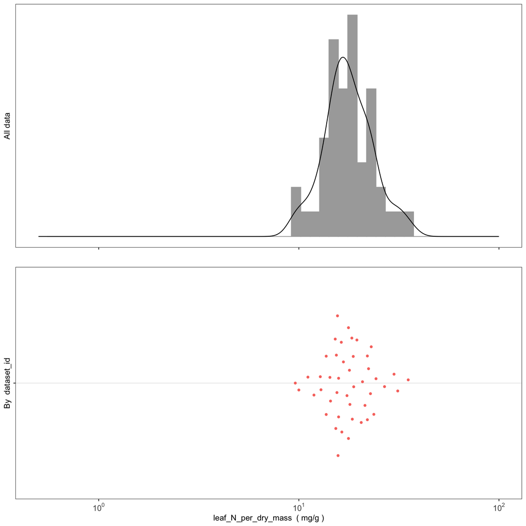

OUTLIERS: 3 of points in your dataset lie in either the bottom or top 2.5 percent of data

**Question:** (section `traits`) Do the data for the trait `leaf_N_per_dry_mass` appear correct?

### leaf_area

We aligned the contributed variable called `leaf size (mm2)` in the data you supplied with the trait `leaf_area` in the AusTraits database, with value_types `mean`.

The original variable was supplied with units `mm2`; these were converted to our standard `mm2`.

The data has the following properties:

- **standardised name**: leaf_area
- **standardised description**: A leaf area trait [TO:0000540] which is the 2-D [PATO:0001709] area [PATO:0001323] of the leaf lamina [PO:0020039] and petiole [PO:0020038]. For some species the area of a leaf analogue is reported, possibly a leaflet [PO:0020049], cladode [PO:0025354], or phyllode [PO:0025335].;The 2-dimensional projected (scanned) area of the surface of a leaf or a leaf analogue (leaflet, cladode, phyllode).
- **label**: Leaf area
- **units**: mm2
- **records**: 45 in this study (of 45 in AusTraits)
- **allowable range**: 0.1 - 1e+07 mm2
- **observed range in this study**: 2071 - 73984 mm2

Data for this trait in this study were collected using the following methods:

- **value_type**: mean
- **replicates**: 3
- **methods**: Leaf size was calculated as the one-sided leaf area (flat bed scanner). It was measured on the first five fully expanded leaves at the tip of each individual.

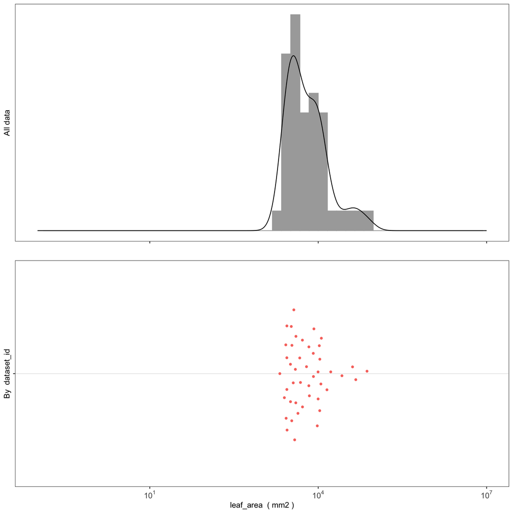

OUTLIERS: 3 of points in your dataset lie in either the bottom or top 2.5 percent of data

**Question:** (section `traits`) Do the data for the trait `leaf_area` appear correct?

### leaf_mass_per_area

We aligned the contributed variable called `LMA (mg mm-2)` in the data you supplied with the trait `leaf_mass_per_area` in the AusTraits database, with value_types `mean`.

The original variable was supplied with units `mg/mm2`; these were converted to our standard `g/m2`.

The data has the following properties:

- **standardised name**: leaf_mass_per_area
- **standardised description**: A leaf morphology trait [TO:0000748] which is the ratio [PATO:0001470] of the leaf dry [PATO:0001824] mass [PATO:0000125] to the leaf [PO:0025034] area [PATO:0001323], measured on an entire leaf, including the entire leaf lamina [PO:0020039] and the petiole [PO:0020038].;The ratio of leaf dry mass to leaf area, measured on an entire leaf including the petiole; LMA. (The inverse of specific leaf area, SLA.)
- **label**: Leaf mass per area
- **units**: g/m2
- **records**: 45 in this study (of 45 in AusTraits)
- **allowable range**: 1 - 3000 g/m2
- **observed range in this study**: 46 - 244 g/m2

Data for this trait in this study were collected using the following methods:

- **value_type**: mean
- **replicates**: 3
- **methods**: LMA was calculated as the leaf dry mass (oven-dried for 48 hours at 65 deg C) divided by leaf size. It was measured on the first five fully expanded leaves at the tip of each individual.

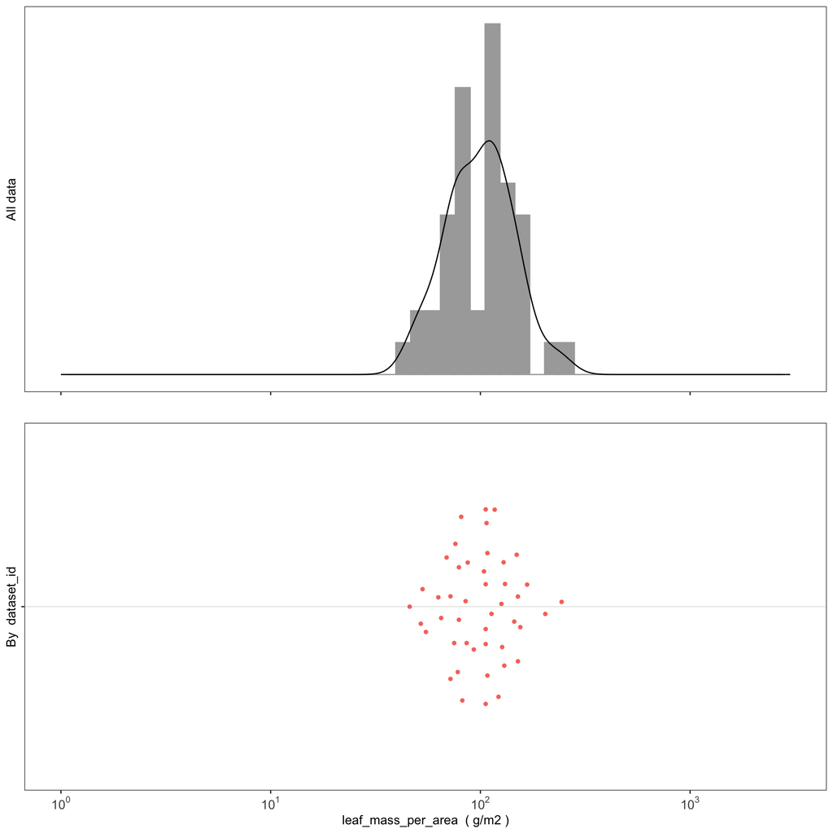

OUTLIERS: 3 of points in your dataset lie in either the bottom or top 2.5 percent of data

**Question:** (section `traits`) Do the data for the trait `leaf_mass_per_area` appear correct?

### seed_dry_mass

We aligned the contributed variable called `Seed mass (mg)` in the data you supplied with the trait `seed_dry_mass` in the AusTraits database, with value_types `mean`.

The original variable was supplied with units `mg`; these were converted to our standard `mg`.

The data has the following properties:

- **standardised name**: seed_dry_mass
- **standardised description**: A seed morphology trait [TO:0000184] which is the dry [PATO:0001824] mass [PATO:0000125] of a mature [PATO:0001701] seed [PO:0009010].;Dry mass of a mature seed, including both oven dried and air-dried samples.
- **label**: Seed dry mass
- **units**: mg
- **records**: 29 in this study (of 29 in AusTraits)
- **allowable range**: 1e-05 - 1e+06 mg
- **observed range in this study**: 0.07 - 48000 mg

Data for this trait in this study were collected using the following methods:

- **value_type**: mean
- **replicates**: unknown
- **methods**: Mean oven-dried seed mass (including seed coat but excluding seed accessories) was estimated for all species with available field material. In total, collections for 17 of 47 species were made. Data for an additional 12 species were drawn from published (Osunkoya et al. 1994; Grubb et al. 1998) and unpublished (P. Juniper, CSIRO Atherton) sources.

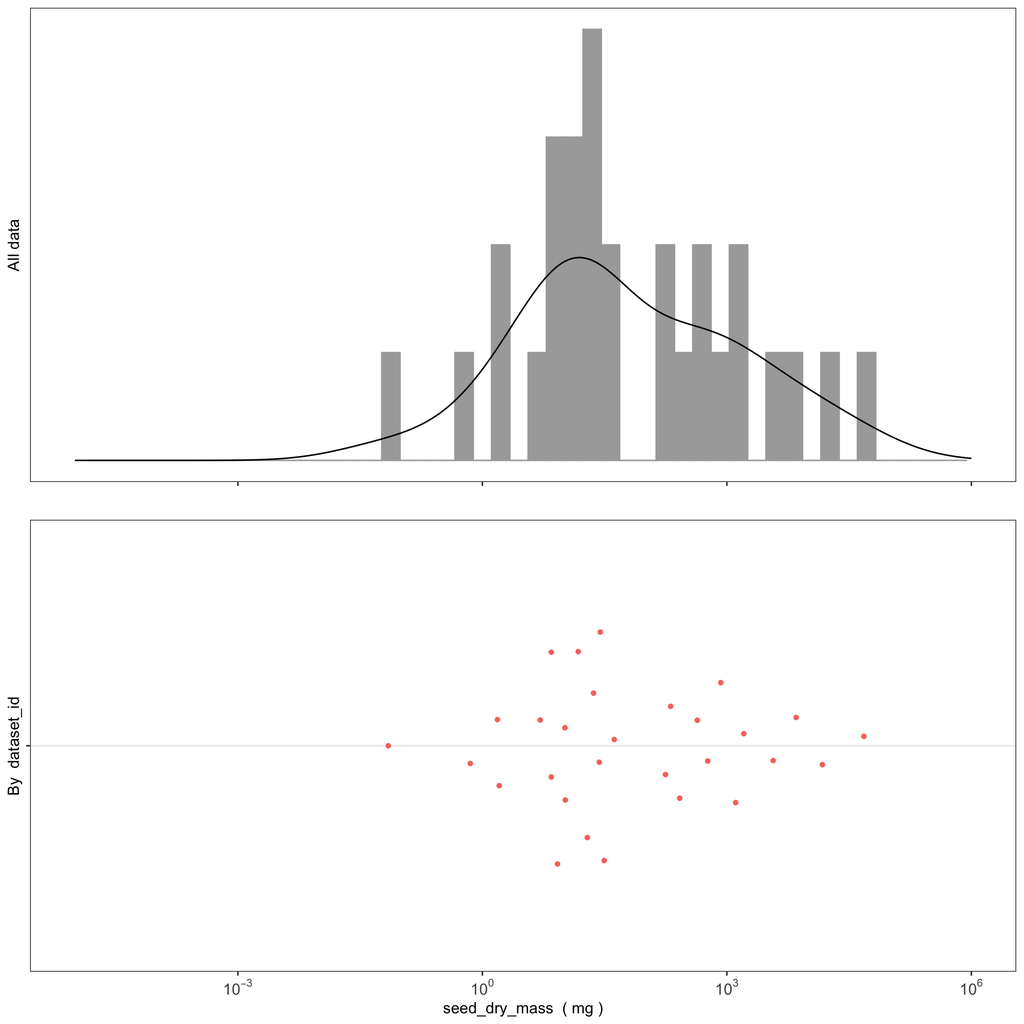

OUTLIERS: 1 of points in your dataset lie in either the bottom or top 2.5 percent of data

**Question:** (section `traits`) Do the data for the trait `seed_dry_mass` appear correct?

**Question:** (section `traits`) Can you provide missing details `replicates` for trait `seed_dry_mass`?

The variable `replicates` is *‘Number of replicate measurements that comprise a recorded trait measurement. A numeric value (or range) is ideal and appropriate if the value type is a `mean`, `median`, `min` or `max`. For these value types, if replication is unknown the entry should be `unknown`. If the value type is `raw_value` the replicate value should be 1. If the trait is categorical or the value indicates a measurement for an entire species (or other taxon) replicate value should be `.na`.’*.

### wood_density

We aligned the contributed variable called `wood density (mg mm-3)` in the data you supplied with the trait `wood_density` in the AusTraits database, with value_types `mean`.

The original variable was supplied with units `mg/mm3`; these were converted to our standard `mg/mm3`.

The data has the following properties:

- **standardised name**: wood_density
- **standardised description**: A stem morphology trait [TO:0000361] which is the ratio [PATO:0001470] of the mass [PATO:0000125] of a unit of wood [NCIT:C93062] from a stem [PO:0009047] assessed after drying to its volume [PATO:0000918] assessed without drying.;The ratio of wood dry mass to wood fresh volume, measured on a stem segment without bark.
- **label**: Wood density
- **units**: mg/mm3
- **records**: 45 in this study (of 45 in AusTraits)
- **allowable range**: 0.05 - 1.4 mg/mm3
- **observed range in this study**: 0.23 - 0.843 mg/mm3

Data for this trait in this study were collected using the following methods:

- **value_type**: mean
- **replicates**: 3
- **methods**: Wood density was calculated using 40-60 mm stem segments taken 250 mm and 1000 mm back along a branch from the branch tip. Fresh samples were refrigerated before processing. After removing bark material, the volume of each wood sample was determined using Archimedes’ principle (Hacke et al. 2000). Samples were submerged in a water-filled container on a balance. The weight change (mg) recorded during submersion corresponds to the mass of water displaced, which can be converted to a volume using the formula, displacement weight (mg)/0.998 (mg/mm3), where 0.998 mg/mm3 is the density of water at 20 deg C. Samples were then dried for 4 days at 60 deg C before weighing.

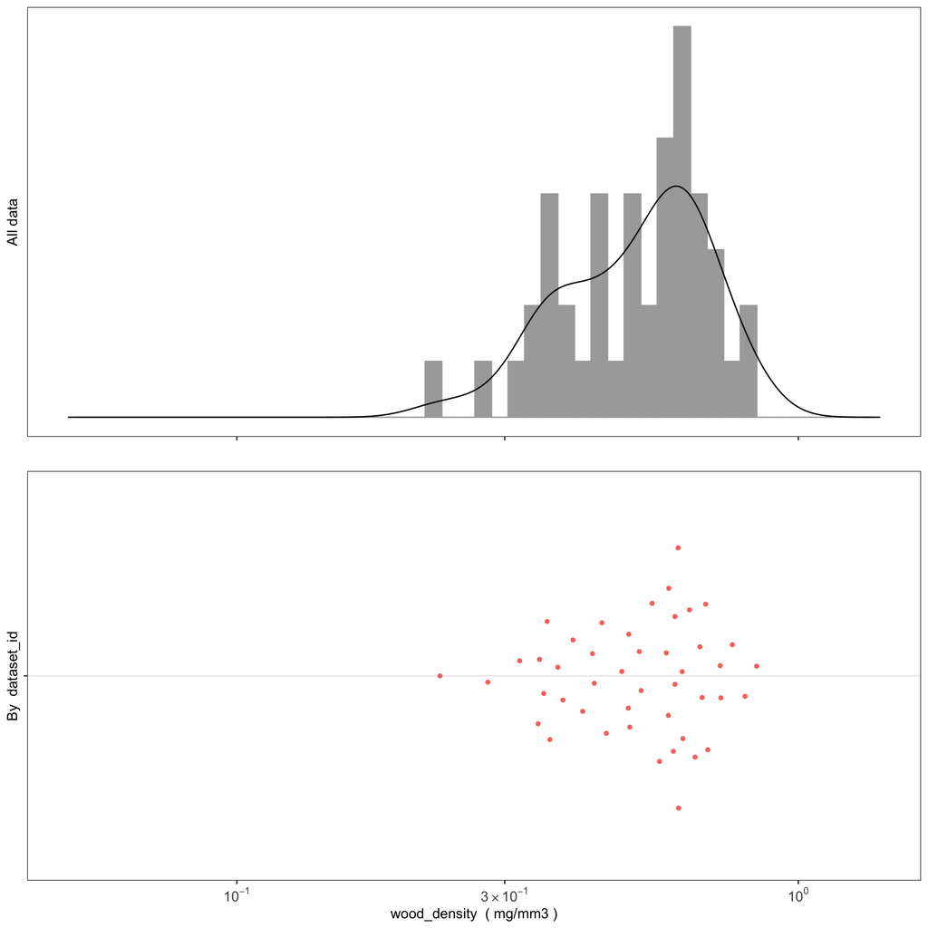

OUTLIERS: 3 of points in your dataset lie in either the bottom or top 2.5 percent of data

**Question:** (section `traits`) Do the data for the trait `wood_density` appear correct?

## Categorical traits

No categorical traits data are currently available in this dataset.

# Taxon list

We have records on the following taxa from your study. We have attempted to align taxon names in this study with the Australian Plant Census (APC) or Australian Plant Names Index (APNI).

## Full taxa list

The table below shows the table of all taxa in this study, where possible using the name aligned with the APC. Columns are as follows:

| key | value |
| --- | --- |
| taxon_name | Scientific name of the taxon on which traits were sampled, without authorship. When possible, this is the currently accepted (botanical) or valid (zoological) scientific name, but might also be a high… |
| taxonomic_reference | Name of the taxonomy (tree) that contains this concept. ie. APC, AusMoss etc. |
| taxon_rank | The taxonomic rank of the most specific name in the scientific name. |
| trinomial | The infraspecific taxon name match for an original name. This column is assigned `na` for taxon name that are at a broader taxonomic_resolution. |
| binomial | The species-level taxon name match for an original name. This column is assigned `na` for taxon name that are at a broader taxonomic_resolution. |
| genus | Genus of the taxon without authorship. |
| family | Family of the taxon. |
| taxon_distribution | Known distribution of the taxon, by Australian state. |
| establishment_means | Statement about whether an organism or organisms have been introduced to a given place and time through the direct or indirect activity of modern humans. |
| taxonomic_status | The status of the use of the scientificName as a label for the taxon in regard to the ‘accepted (or valid) taxonomy’. The assigned taxonomic status must be linked to a specific taxonomic reference tha… |
| scientific_name | The full scientific name, with authorship and date information if known. |
| scientific_name_authorship | The authorship information for the scientific name formatted according to the conventions of the applicable. |
| taxon_id | An identifier for the set of taxon information (data associated with the taxon class). May be a global unique identifier or an identifier specific to the data set. Must be resolvable within this datas… |
| scientific_name_id | An identifier for the set of taxon information (data associated with the taxon class). May be a global unique identifier or an identifier specific to the data set. Must be resolvable within this datas… |

Clicking on the name will take you to the relevant taxonomic record in the APC or APNI, where known:

| taxon_name | taxonomic_reference | taxon_rank | trinomial | binomial | genus | family | taxon_distribution | establishment_means | taxonomic_status | scientific_name | scientific_name_authorship | taxon_id | scientific_name_id |
| --- | --- | --- | --- | --- | --- | --- | --- | --- | --- | --- | --- | --- | --- |
| [Acacia celsa](https://id.biodiversity.org.au/taxon/apni/51436506) | APC | Species |  | Acacia celsa | Acacia | Fabaceae | Qld | native | accepted | Acacia celsa Tindale | Tindale | https://id.biodiversity.org.au/taxon/apni/51436506 | https://id.biodiversity.org.au/name/apni/154988 |
| Acmena graveolens |  |  |  |  | Acmena |  |  |  |  |  |  |  |  |
| [Acronychia acidula](https://id.biodiversity.org.au/node/apni/2913200) | APC | Species |  | Acronychia acidula | Acronychia | Rutaceae | Qld | native | accepted | Acronychia acidula F.Muell. | F.Muell. | https://id.biodiversity.org.au/node/apni/2913200 | https://id.biodiversity.org.au/name/apni/73794 |
| Aleurites rockinghamensis |  |  |  |  | Aleurites |  |  |  |  |  |  |  |  |
| [Alphitonia petriei](https://id.biodiversity.org.au/node/apni/2887911) | APC | Species |  | Alphitonia petriei | Alphitonia | Rhamnaceae | Qld, NSW | native | accepted | Alphitonia petriei Braid & C.T.White | Braid & C.T.White | https://id.biodiversity.org.au/node/apni/2887911 | https://id.biodiversity.org.au/name/apni/82935 |
| Alstonia scholaris |  |  |  |  | Alstonia |  |  |  |  |  |  |  |  |
| Argyrodendron peralatum |  |  |  |  | Argyrodendron |  |  |  |  |  |  |  |  |
| Atractocarpus hirtus |  |  |  |  | Atractocarpus |  |  |  |  |  |  |  |  |
| Brombya platynema |  |  |  |  | Brombya |  |  |  |  |  |  |  |  |
| Cardwellia sublimis |  |  |  |  | Cardwellia |  |  |  |  |  |  |  |  |
| Castanospermum australe |  |  |  |  | Castanospermum |  |  |  |  |  |  |  |  |
| Cleistanthus myrianthus |  |  |  |  | Cleistanthus |  |  |  |  |  |  |  |  |
| Cryptocarya laevigata |  |  |  |  | Cryptocarya |  |  |  |  |  |  |  |  |
| Cryptocarya mackinnoniana |  |  |  |  | Cryptocarya |  |  |  |  |  |  |  |  |
| Cryptocarya murrayi |  |  |  |  | Cryptocarya |  |  |  |  |  |  |  |  |
| Dendrocnide moroides |  |  |  |  | Dendrocnide |  |  |  |  |  |  |  |  |
| Elaeocarpus grandis |  |  |  |  | Elaeocarpus |  |  |  |  |  |  |  |  |
| Endiandra leptodendron |  |  |  |  | Endiandra |  |  |  |  |  |  |  |  |
| Endiandra microneura |  |  |  |  | Endiandra |  |  |  |  |  |  |  |  |
| Gillbeea adenopetala |  |  |  |  | Gillbeea |  |  |  |  |  |  |  |  |
| [Glochidion hylandii](https://id.biodiversity.org.au/node/apni/2889113) | APC | Species |  | Glochidion hylandii | Glochidion | Phyllanthaceae | Qld | native | accepted | Glochidion hylandii Airy Shaw | Airy Shaw | https://id.biodiversity.org.au/node/apni/2889113 | https://id.biodiversity.org.au/name/apni/78303 |
| Haplostichanthus submontanus |  |  |  |  | Haplostichanthus |  |  |  |  |  |  |  |  |
| Harpullia rhyticarpa |  |  |  |  | Harpullia |  |  |  |  |  |  |  |  |
| Hernandia albiflora |  |  |  |  | Hernandia |  |  |  |  |  |  |  |  |
| Homalanthus novo-guineensis |  |  |  |  | Homalanthus |  |  |  |  |  |  |  |  |
| Ixora biflora |  |  |  |  | Ixora |  |  |  |  |  |  |  |  |
| Lasianthus strigosus |  |  |  |  | Lasianthus |  |  |  |  |  |  |  |  |
| Litsea leefeana |  |  |  |  | Litsea |  |  |  |  |  |  |  |  |
| Macaranga tanarius |  |  |  |  | Macaranga |  |  |  |  |  |  |  |  |
| Mallotus mollissimus |  |  |  |  | Mallotus |  |  |  |  |  |  |  |  |
| Medicosma sessiliflora |  |  |  |  | Medicosma |  |  |  |  |  |  |  |  |
| Melastoma cyanoides |  |  |  |  | Melastoma |  |  |  |  |  |  |  |  |
| [Melicope elleryana](https://id.biodiversity.org.au/node/apni/2913641) | APC | Species |  | Melicope elleryana | Melicope | Rutaceae | WA, NT, Qld, NSW | native | accepted | Melicope elleryana (F.Muell.) T.G.Hartley | (F.Muell.) T.G.Hartley | https://id.biodiversity.org.au/node/apni/2913641 | https://id.biodiversity.org.au/name/apni/118560 |
| Myristica insipida |  |  |  |  | Myristica |  |  |  |  |  |  |  |  |
| Neolitsea dealbata |  |  |  |  | Neolitsea |  |  |  |  |  |  |  |  |
| Pittosporum rubiginosum |  |  |  |  | Pittosporum |  |  |  |  |  |  |  |  |
| Polyscias australiana |  |  |  |  | Polyscias |  |  |  |  |  |  |  |  |
| Psychotria dallachiana |  |  |  |  | Psychotria |  |  |  |  |  |  |  |  |
| Psychotria sp. Utchee Creek (H.Flecker NQNC5313) |  |  |  |  | Psychotria |  |  |  |  |  |  |  |  |
| Quassia baileyana |  |  |  |  | Quassia |  |  |  |  |  |  |  |  |
| Rhodomyrtus trineura |  |  |  |  | Rhodomyrtus |  |  |  |  |  |  |  |  |
| Rockinghamia angustifolia |  |  |  |  | Rockinghamia |  |  |  |  |  |  |  |  |
| Syzygium gustavioides |  |  |  |  | Syzygium |  |  |  |  |  |  |  |  |
| Syzygium sayeri |  |  |  |  | Syzygium |  |  |  |  |  |  |  |  |
| Trema aspera |  |  |  |  | Trema |  |  |  |  |  |  |  |  |

To create the list of aligned taxa, we needed to make some taxonomic changes. This involved two stages.

- **Stage 1**: Where possible (i.e. there was no or only a few characters difference), the name you supplied was matched automatically with a known name in APC or APNI. In other cases we may have aligned the taxa by searching for an appropriate match. Such changes are documented in the study metadata file. The variable `cleaned_name` shows the updated name. The variable `d1` shows the number of characters difference between the `original_name` and `cleaned_name`.
- **Stage 2**: Once aligned with a known name, we used the APC to update the `cleaned_name` to an accepted name. The taxonomic status of the cleaned name is indicated in column `status cleaned name`. If accepted, no change was made. If it is a synonym or otherwise, the name was changed according to the recommendation given in the APC. Where they existed, we preferred to take the accepted status of an `cleaned_name`, if it existed. Alternative status values are indicated in brackets. This indicate if alternative uses of the name were ever applied.

Links on `cleaned_name` and `taxon_name` take you to the APC or APNI record for that name.

| original_name | d1 | cleaned_name | d2 | taxon_name | status cleaned name |
| --- | --- | --- | --- | --- | --- |

## Unknown taxa

We were unable to find taxonomic matches for the following taxa in the data. Where genus and family are shown, the specified genus aligns with an accepted genus. The term `unplaced` appears as the `status` for names on the APNI list, but not yet reviewed by the APC.

| taxon_name | taxonomic_reference | taxon_rank | trinomial | binomial | genus | family | taxonomic_status | scientific_name | scientific_name_authorship |
| --- | --- | --- | --- | --- | --- | --- | --- | --- | --- |
| Acmena graveolens |  |  |  |  | Acmena |  |  |  |  |
| Aleurites rockinghamensis |  |  |  |  | Aleurites |  |  |  |  |
| Alstonia scholaris |  |  |  |  | Alstonia |  |  |  |  |
| Argyrodendron peralatum |  |  |  |  | Argyrodendron |  |  |  |  |
| Atractocarpus hirtus |  |  |  |  | Atractocarpus |  |  |  |  |
| Brombya platynema |  |  |  |  | Brombya |  |  |  |  |
| Cardwellia sublimis |  |  |  |  | Cardwellia |  |  |  |  |
| Castanospermum australe |  |  |  |  | Castanospermum |  |  |  |  |
| Cleistanthus myrianthus |  |  |  |  | Cleistanthus |  |  |  |  |
| Cryptocarya laevigata |  |  |  |  | Cryptocarya |  |  |  |  |
| Cryptocarya mackinnoniana |  |  |  |  | Cryptocarya |  |  |  |  |
| Cryptocarya murrayi |  |  |  |  | Cryptocarya |  |  |  |  |
| Dendrocnide moroides |  |  |  |  | Dendrocnide |  |  |  |  |
| Elaeocarpus grandis |  |  |  |  | Elaeocarpus |  |  |  |  |
| Endiandra leptodendron |  |  |  |  | Endiandra |  |  |  |  |
| Endiandra microneura |  |  |  |  | Endiandra |  |  |  |  |
| Gillbeea adenopetala |  |  |  |  | Gillbeea |  |  |  |  |
| Haplostichanthus submontanus |  |  |  |  | Haplostichanthus |  |  |  |  |
| Harpullia rhyticarpa |  |  |  |  | Harpullia |  |  |  |  |
| Hernandia albiflora |  |  |  |  | Hernandia |  |  |  |  |
| Homalanthus novo-guineensis |  |  |  |  | Homalanthus |  |  |  |  |
| Ixora biflora |  |  |  |  | Ixora |  |  |  |  |
| Lasianthus strigosus |  |  |  |  | Lasianthus |  |  |  |  |
| Litsea leefeana |  |  |  |  | Litsea |  |  |  |  |
| Macaranga tanarius |  |  |  |  | Macaranga |  |  |  |  |
| Mallotus mollissimus |  |  |  |  | Mallotus |  |  |  |  |
| Medicosma sessiliflora |  |  |  |  | Medicosma |  |  |  |  |
| Melastoma cyanoides |  |  |  |  | Melastoma |  |  |  |  |
| Myristica insipida |  |  |  |  | Myristica |  |  |  |  |
| Neolitsea dealbata |  |  |  |  | Neolitsea |  |  |  |  |
| Pittosporum rubiginosum |  |  |  |  | Pittosporum |  |  |  |  |
| Polyscias australiana |  |  |  |  | Polyscias |  |  |  |  |
| Psychotria dallachiana |  |  |  |  | Psychotria |  |  |  |  |
| Psychotria sp. Utchee Creek (H.Flecker NQNC5313) |  |  |  |  | Psychotria |  |  |  |  |
| Quassia baileyana |  |  |  |  | Quassia |  |  |  |  |
| Rhodomyrtus trineura |  |  |  |  | Rhodomyrtus |  |  |  |  |
| Rockinghamia angustifolia |  |  |  |  | Rockinghamia |  |  |  |  |
| Syzygium gustavioides |  |  |  |  | Syzygium |  |  |  |  |
| Syzygium sayeri |  |  |  |  | Syzygium |  |  |  |  |
| Trema aspera |  |  |  |  | Trema |  |  |  |  |

**Question:** (section `taxonomic_updates`) Do these taxonomic alignments and corrections look reasonable?

# Review of questions

Here is a summary of the questions we would like answers to. Clicking on the links will take you back to the appropriate spot in the document. Please copy and past these into an email when you respond.

# Session information

The technical information below may useful for us for the sake of reproducibility, but you don’t need to worry about it!

This report was generated using the data from the commit 6c73238d8d048781d9a4f5239a03813be313f0dd